# Assignment 5 - Helmetsberger Maria & Gstoettenmayr Jonas

### 3.3) Our CNN

```python
import keras_tuner as kt
import keras.optimizers as opt
```

#### Hypermodel

We decided to do a Hyperband Search for the best Parameters for our Custom CNN model. The input is pretty clear, its just our inputshape, then the data augmentation and afterwards we have the numbers of con Blocks which are random in between 2, 3 and 4, the filters which can be ether 16, 32, 64 and I also put the activation function in there (relu, elu and selu).

We decided to also use BatchNormalization, there is also always an option that it makes another conv layers instead of just one, also with batchNormalization.

After that we always have MaxPooling and Drop out.

Afterwards we have the Dense Units and the Dense Dropout, we only have 1 or 2 layers, as we only have 3 classes. Our Dense Units can be 16, 32, 64 or 128 and our dropout can be from min 0.0 to max 0.5. THe output layer is a Dense layer with 3 neurons and an activation of softmax.

We also have options between the optimizer and learningrate, optimizer can be adam or lion and the learning rate is in between 5e-4 and 25e-4

Our loss here is the sparse categorical crossentropy.

Our Hyperparameters aren't the biggest ones, that is because our Dataset isn't the biggest, so those parameters made the most sense for our Data. Afterwards we did Hyberband Search anyways so that we would figure out which Parameters are the best.

```python
def hypermodel(hp):
    inputs = keras.layers.Input(shape=(128, 128, 3))

    # Add data augmentation
    x = data_augmentation(inputs)

    # Convolutional blocks
    num_conv_blocks = hp.Choice('num_conv_blocks', [2, 3, 4])
    filters = hp.Choice('initial_filters', [16, 32, 64])
    activation_function = hp.Choice('activation', ['relu', 'elu', 'selu'])


    for i in range(num_conv_blocks):
        # Conv layers in each block
        x = keras.layers.Conv2D(
            filters=filters * (2 ** i),
            kernel_size=hp.Choice(f'kernel_size_{i}', [3, 5]),
            padding='same'
        )(x)
        x = keras.layers.BatchNormalization()(x)
        x = keras.layers.Activation(hp.Choice('activation', ['relu', 'elu', 'selu']))(x)

        # Optional second conv in block
        if hp.Boolean(f'double_conv_{i}'):
            x = keras.layers.Conv2D(
                filters=filters * (2 ** i),
                kernel_size=3,
                padding='same'
            )(x)
            x = keras.layers.BatchNormalization()(x)
            x = keras.layers.Activation(hp.Choice('activation', ['relu', 'elu', 'selu']))(x)

        # Pooling
        x = keras.layers.MaxPooling2D(pool_size=2)(x)
        x = keras.layers.Dropout(hp.Float('conv_dropout', 0.0, 0.3, sampling='linear'))(x)

    # Flatten
    x = keras.layers.Flatten()(x)

    # Dense layers
    dense_units = hp.Choice('dense_units', [16, 32, 64, 128])
    dense_dropout = hp.Float('dense_dropout', min_value=0.0, max_value=0.5, sampling='linear')

    for i in range(hp.Choice('num_dense_layers', [1, 2])):
        x = keras.layers.Dense(dense_units)(x)
        x = keras.layers.Activation(activation_function)(x)
        if dense_dropout > 0:
            x = keras.layers.Dropout(dense_dropout)(x)

    # Output layer
    outputs = keras.layers.Dense(3, activation='softmax')(x)
    model = keras.Model(inputs=inputs, outputs=outputs, name='cnn_hypermodel')

    # Optimizer
    optimizer_choice = hp.Choice('optimizer', ['adam', 'lion'])
    learning_rate = hp.Float('learning_rate', min_value=5e-4, max_value=25e-4, sampling='linear')

    if optimizer_choice == 'adam':
        optimizer = opt.Adam(learning_rate=learning_rate)
    else:
        optimizer = opt.Lion(learning_rate=learning_rate)

    model.compile(
        optimizer=optimizer,
        loss='sparse_categorical_crossentropy',
        metrics=['accuracy']
    )

    return model
```

```python
tuner = kt.Hyperband(
    hypermodel=hypermodel,
    objective="val_accuracy",
    max_epochs=10,
    hyperband_iterations=2,
    seed=42,
    project_name="hyperbandCNN",
)
```

```python
tuner.search(
    train_ds,
    epochs=10,
    validation_data=val_ds,
    verbose=1
)
```

```
Trial 60 Complete [00h 00m 19s]
val_accuracy: 0.4693877696990967

Best val_accuracy So Far: 0.6530612111091614
Total elapsed time: 00h 19m 06s
```

```python
# Get best model
best_tuned = tuner.get_best_models()[0]
best_hps = tuner.get_best_hyperparameters(num_trials=1)[0]

print("\nBest hyperparameters:")
best_hps.values
```

```
Best hyperparameters:
```

```
{'num_conv_blocks': 4,
 'initial_filters': 16,
 'activation': 'elu',
 'kernel_size_0': 3,
 'double_conv_0': True,
 'conv_dropout': 0.20527569192092418,
 'kernel_size_1': 3,
 'double_conv_1': False,
 'dense_units': 64,
 'dense_dropout': 0.02685208503205294,
 'num_dense_layers': 2,
 'optimizer': 'adam',
 'learning_rate': 0.0005336500117448142,
 'kernel_size_2': 3,
 'double_conv_2': False,
 'kernel_size_3': 5,
 'double_conv_3': False,
 'tuner/epochs': 10,
 'tuner/initial_epoch': 4,
 'tuner/bracket': 2,
 'tuner/round': 2,
 'tuner/trial_id': '0012'}
```

```python
# Evaluate
test_loss, test_acc = best_tuned.evaluate(test_ds)
print(f"\nTest accuracy: {test_acc:.4f}")
```

```
8/8 ━━━━━━━━━━━━━━━━━━━━ 1s 68ms/step - accuracy: 0.4817 - loss: 1.0838

Test accuracy: 0.4590
```

```
==================================================
  Custom - Classification Results
==================================================
  Test Loss:     1.0994
  Test Accuracy: 0.4590 (45.90%)
==================================================

              precision    recall  f1-score   support

         cat       0.38      0.23      0.29        22
         dog       0.54      0.35      0.42        20
         fox       0.46      0.84      0.59        19

    accuracy                           0.46        61
   macro avg       0.46      0.47      0.43        61
weighted avg       0.46      0.46      0.43        61
```

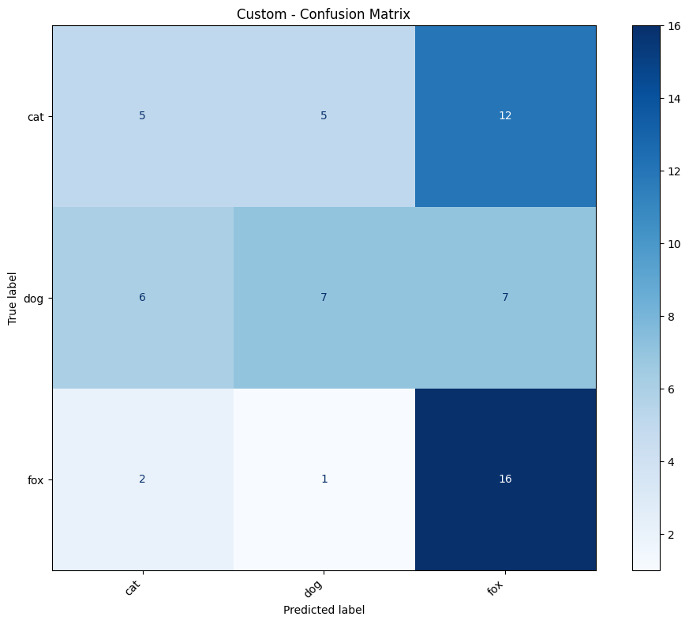

```
(1.099385380744934, 0.4590163826942444)
```

```python
eval_classification(best_tuned, test_ds, test.class_names,"Custom")
```